# DCIR05: Discovering the OkCupid Dataset and Chicago Food Inspection Data

Yuda Jiang (yudaj2@illinois.edu)

11/19/2019

# Analysis 1 - OkCupid Data: Discovering the users

## Introduction

For analyzing the essay questions in the dataset, we are interested to know a couple of questions. What are the ‘common’ six things single people can’t live without?

Our questions mainly focus on the words in each essay question. In order to answer these questions, we plan to use data visualizations, sub-setting, and text mining techniques.

## Analysis

### Data

```r
single_data = filter(okcupid, status == "single", income != -1)
```

### Visualization

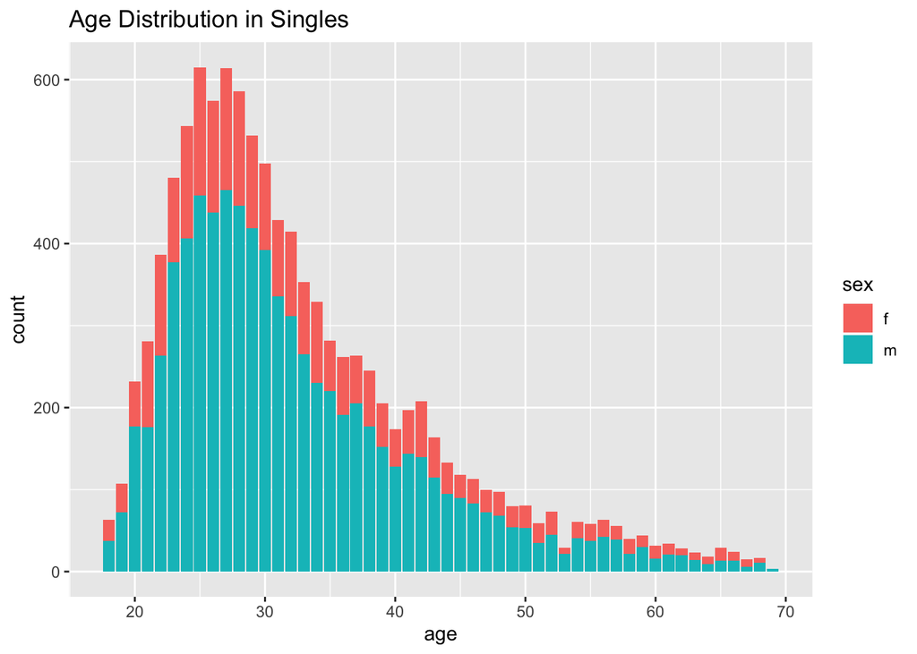

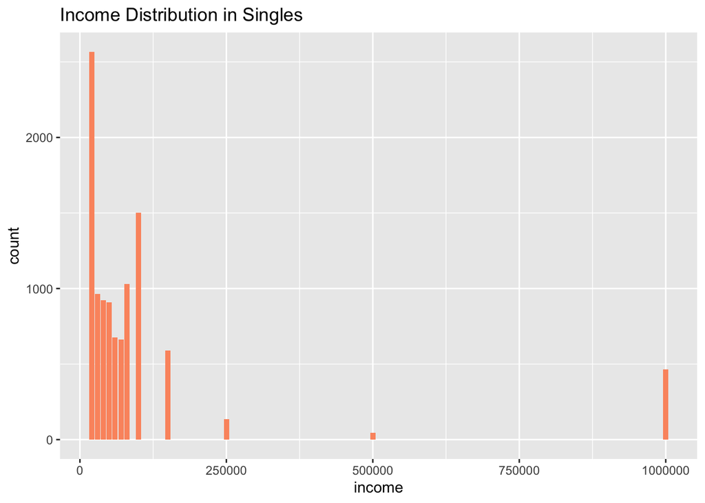

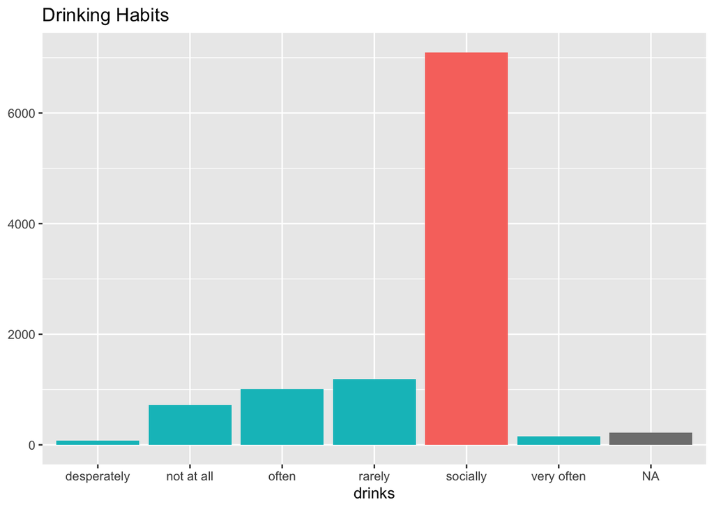

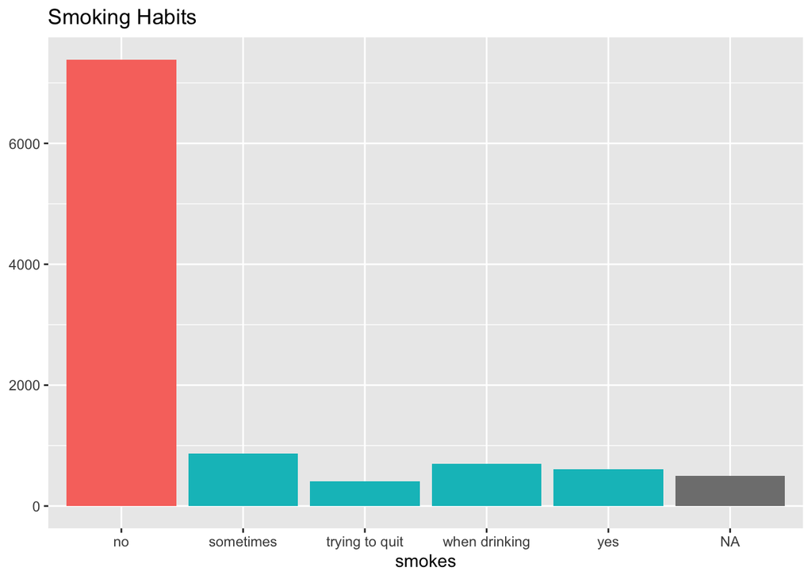

[figure not shown]

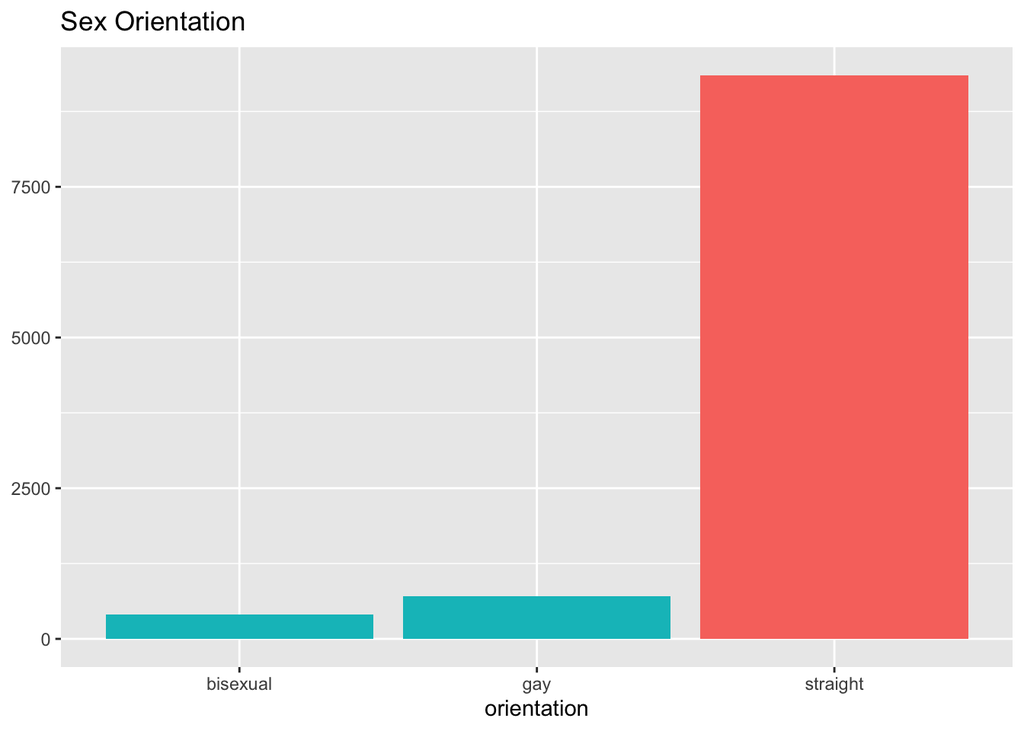

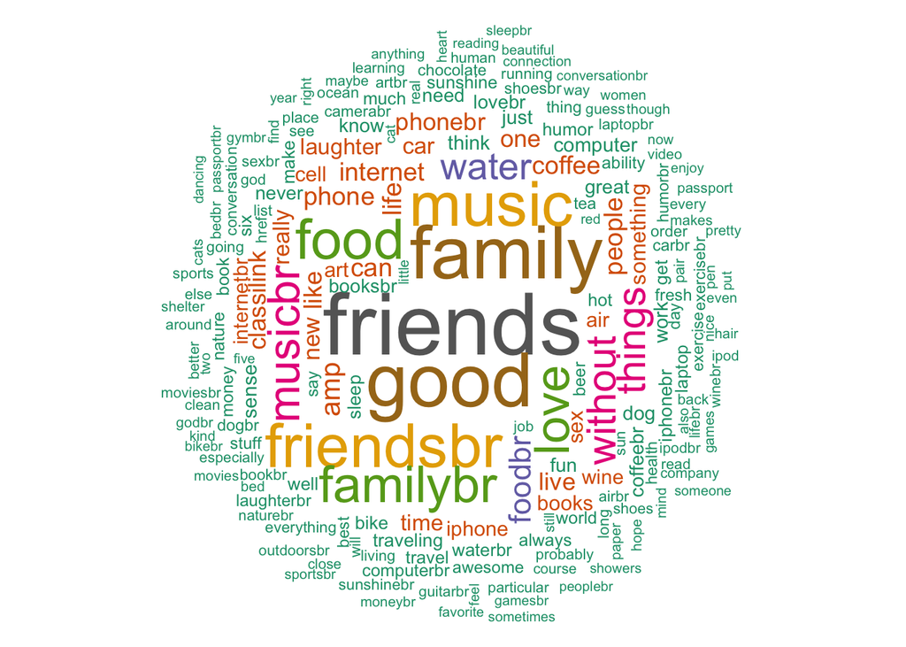

From the wordcloud we generated from text mining, we can see that the things that these groups cannot live without are mostly friends, families, music, food, love, and tech stuff.

## Conclusion

From the text analysis we did on one of the essay questions, we found the most important things in their lives are family, friends, love, music, food, and technology products.

There are some limitations of this analysis. First, we are unable to process text analysis using a large dataset. Second, some users refuse to disclose their income, making the income distribution a little bit biased. Last but not least, we can build models based text analysis to predict the users’ preference.

# Analysis 2 - Exploring the Chicago Food Data

## Abstract

Food quality has always been a public health issue and essential for determining a city’s publicity. This dataset includes inspection data for different kinds of facilities types such as restaurants, schools, cafes, and etc. Lots of facilities in this dataset are under high risk which could affect public’s health. For this analysis, we are interested in finding the inspection situation for restaurants and schools. We want to focus on these categories because people often go to restaurants and it is important to know the health situation of the restaurants across the city. The reason we pick schools is that the health of kids is essential to the society.

## Introduction

The Chicago Food Inspection data includes 187787 observations and 22 variables. Some important columns include risk levels, results, violations and zip zodes. We want to explore the inspection situation in both restaurants and schools. We cleaned the data and filtered out restaurant inspection data and school inspection data.

For the analysis, we are curious to know if these two categories are under high risks and their inspection results. We are also interested in knowing the top inspection types and top violation codes for each two facility type and if they have difference between each other. The problem we want to solve is to help these two types of facilities to better maintain their sanitary conditions.

## Analysis

### Data

```r
# Filtering the facility type
data_rest = filter(food_data, type == "Restaurant")
```

```r
# Filtering the facility type to school
data_sch = filter(food_data, type == "School")
```

### Visualization

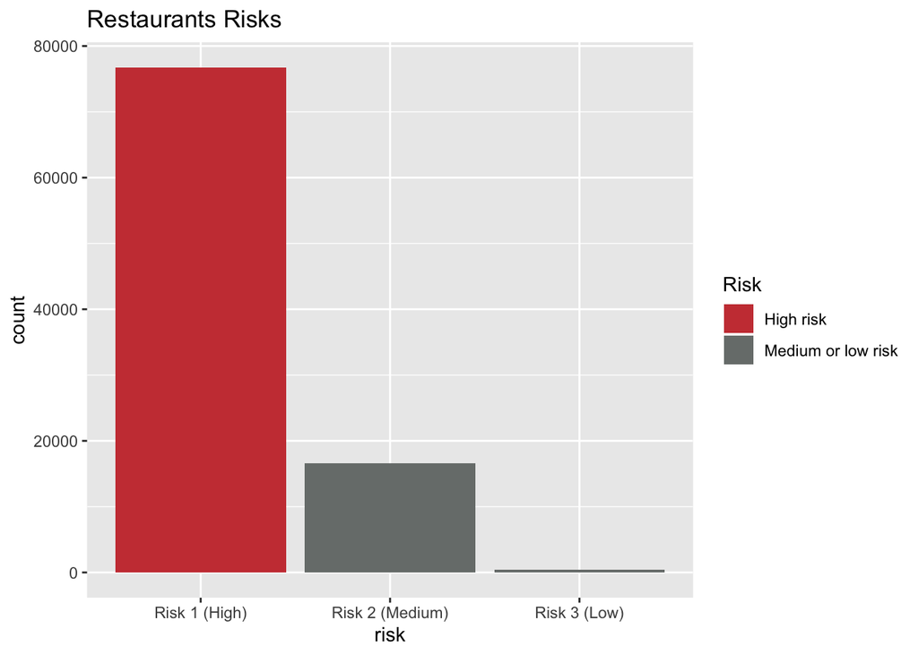

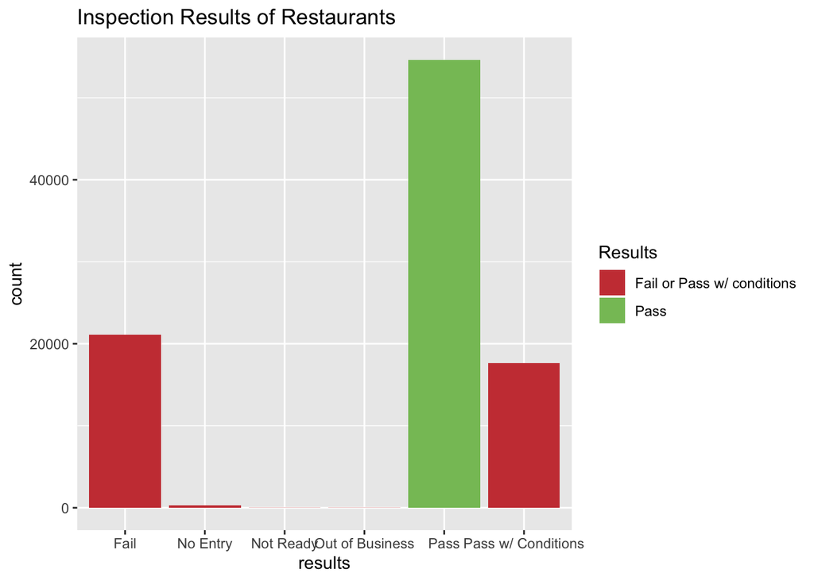

As the plots shown above, we can see the most restaurants are under **high** risk and about 60% of the restaurants **fully passed** the inspections.

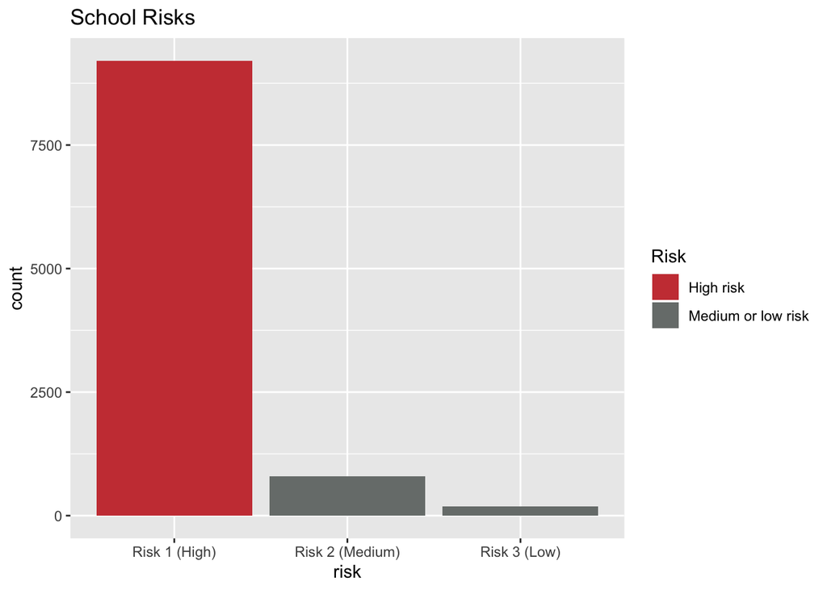

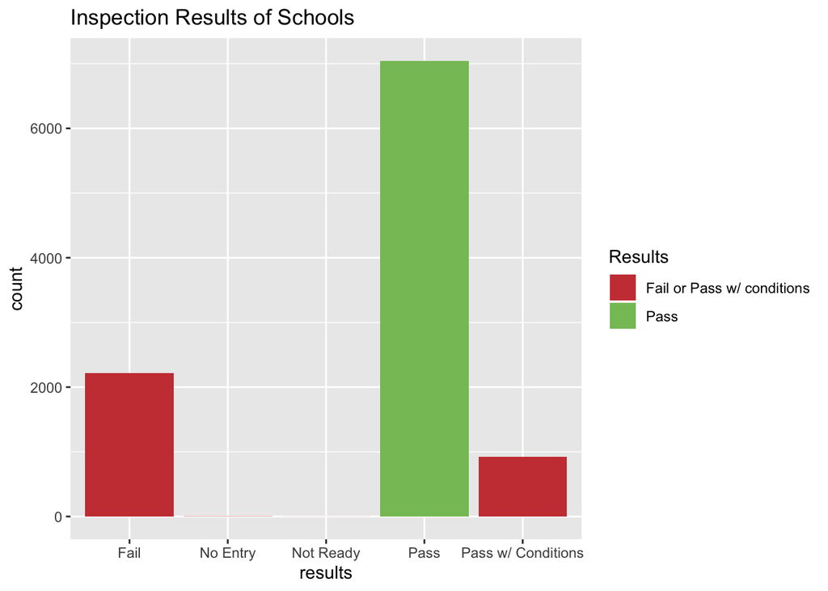

As the plots shown above, we can see that the number of schools is way smaller compared to the number of restaurants. A large amount of schools are under high risk yet about 70% of the schools **fully passed** the inspections

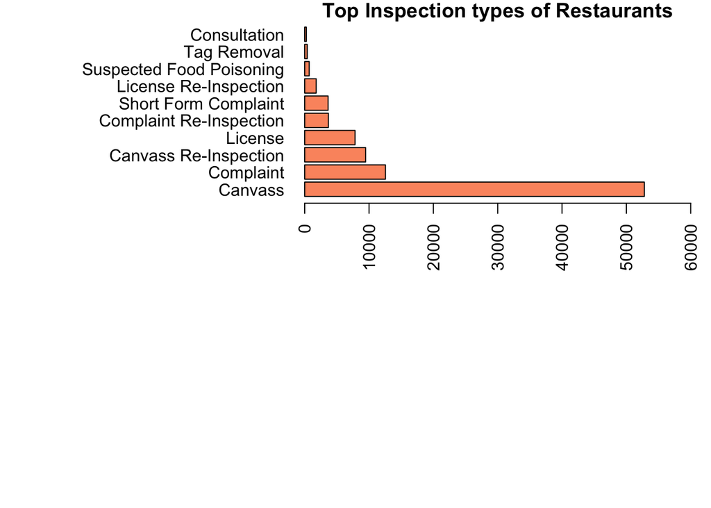

As we can see here in the plot, the most frequent inspection type is regular inspection. Only a tiny portion of the restaurants were inspected due to tags remove.

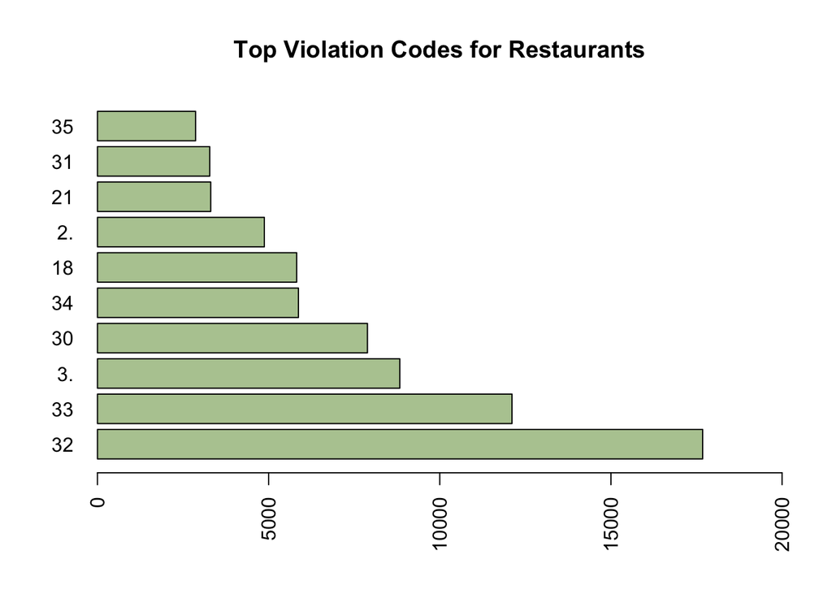

```r
rest_num = substr(data_rest$violations, start = 1, stop = 2)
data_rest = cbind(rest_num, data_rest)
table3 <- sort(table(data_rest$rest_num))
table3 <- rev(table3)[1:10]
barplot(
  table3,
  las = 2,
  col = "#B5CAA0",
  main = "Top Violation Codes for Restaurants",
  horiz = TRUE,
  xlim = c(0, 20000)
)
```

The most frequent violation that restaurant breaks is code 32th: *Food and non-food contact surfaces properly designed, constructed and maintained.* The second most frequent violation code that restaurant breaks is code 33th: *Food and non-food contact equipment utensils clean, free of abrasive detergents.*

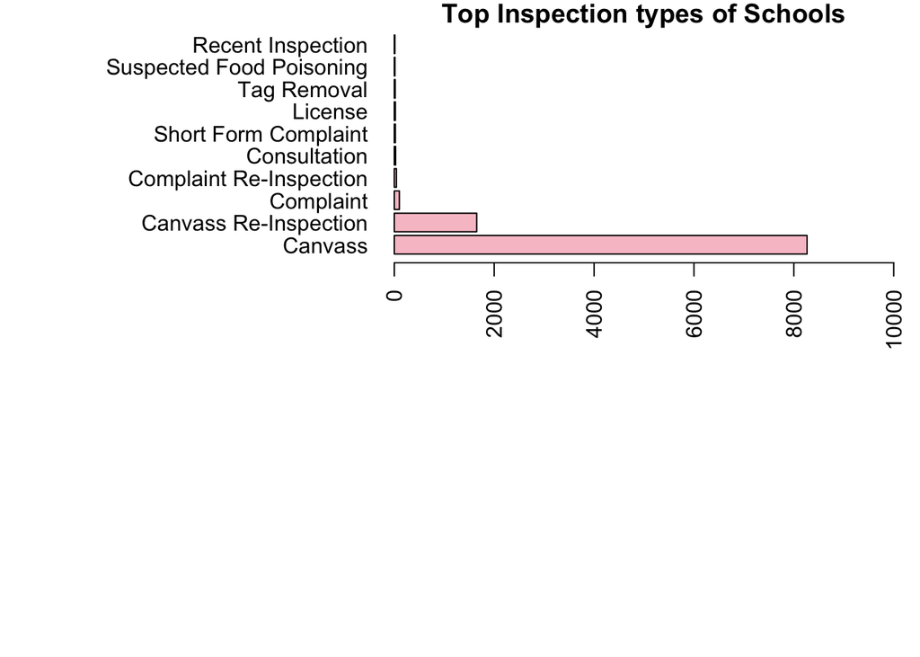

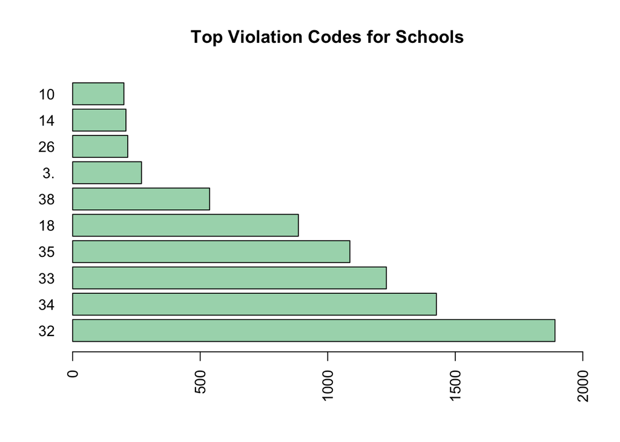

The most frequent violation that school breaks is also code 32th: *Food and non-food contact surfaces properly designed, constructed and maintained.* The second most frequent violation is code 34th: *Floors: constructed per code, cleaned, good repair, coving installed, dust-less cleaning methods used.*

## Conclusion

From the EDA Analysis above, we can conclude that most restaurants and schools that are under high risks passed the inspections eventually. The most frequent types of inspections for restaurants come from regular checking and customer complaints. Comparing to schools, restaurants have more complaints re-inspections. We can interpret that the school committee takes inspection and health issue more seriously so they have smaller distributions in complaints re-inspections.

Moreover, we found that both restaurants and schools break the code 32 most frequently. These types of facilities should pay special attention to their Food and non-food contact surfaces. To be more specific, restaurants should also keep their equipment clean and schools should keep their floors clean.